# WBC Walkthrough

Jack Barrington

Mon 11 April 2022

# Intro

This is a brief walkthrough of the r code that was used to analyse the data in our systematic review looking at associations between inflammatory biomarkers and outcome in intracerebral haemorrhage.

All credit for design and implementation of the systematic review goes to the brilliance of first author (Caoimhe) and last author (Neshika).

I am publishing this code for absolute transparency of our project and in case it helps other MA noobs (like myself) run through an MA for the first time.

I have used the metafor package to perform this meta-analysis and everything you would want to know about metafor is provided in a very clear and concise way on the associated website: https://www.metafor-project.org/doku.php/metafor

Here we go. First up, the packages that you will need for this project.

```r
# Loading required packages
library(here)
library(tidyverse)
library(metafor)
library(kableExtra)
```

## Data Table

Next comes the table containing all of the data we extracted for studies measuring WBC and outcome.

N.B. you can just change the filtering strategy in the code below to any of the biomarkers we measured!

I have provided the data in a clean_data RDS file but it originally came from a messy excel spreadsheet. If you would like to have a go at cleaning a messy excel sheet or critiquing my (quite poor) data wrangling code then let me know!

| Study id | Author | Year | Biomarker units | N | Risk of bias | Male percent | Ivh percent | Age | Ich vol | Nihss | N in poor | N in good | Mean in poor | Sd in poor | Mean in good | Sd in good | Subgroup |
| --- | --- | --- | --- | --- | --- | --- | --- | --- | --- | --- | --- | --- | --- | --- | --- | --- | --- |
| 1 | Delgado | 2006 | Leukocyte count | 78 | 0 | 68.00 | 25.0 | 75.00 | 17.0 | 11.00 | 48 | 30 | 10.40 | 3.500 | 8.50 | 3.000 | High Quality |
| 2 | Perez de la Ossa | 2010 | Leukocyte count (X1000/mmc) | 92 | 1 | 66.30 | 28.2 | 68.04 | 19.8 | NA | 51 | 41 | 8.40 | 2.800 | 8.50 | 1.900 | High Quality |
| 3 | Zhou | 2010 | Leukocyte count (X1000/mmc) | 60 | 1 | 63.30 | 31.7 | 65.90 | NA | NA | 29 | 31 | 8.10 | 1.800 | 7.80 | 2.000 | High Quality |
| 4 | Jiang | 2014 | WBC (X109) | 172 | 2 | 57.56 | 35.5 | 68.40 | 31.9 | 11.00 | 98 | 74 | 7.60 | 2.800 | 7.20 | 2.700 | Low Quality |
| 5 | Tang | 2014 | WBC (103/ul) | 43 | 3 | 65.10 | NA | 60.10 | NA | 13.37 | 20 | 23 | 10.30 | 2.800 | 10.20 | 4.400 | Low Quality |
| 6 | Xiong | 2015 | Leukocyte count (x1000/mmc) | 81 | 1 | 59.25 | 22.2 | 60.70 | NA | NA | 38 | 43 | 7.45 | 1.210 | 7.08 | 1.790 | High Quality |
| 7 | He | 2018 | Leukocyte count (109/L) | 251 | 1 | 56.20 | 48.9 | 66.60 | 10.0 | NA | 161 | 90 | 7.00 | 1.800 | 7.10 | 2.200 | High Quality |
| 8 | Chen | 2019 | WBC (X109/L) | 106 | 0 | 57.50 | 28.3 | 67.00 | 14.0 | 10.00 | 56 | 50 | 9.10 | 2.800 | 8.40 | 2.800 | High Quality |
| 9 | Rodriguez-Castro | 2019 | Leukocytes (x103/mL) | 961 | 4 | 57.10 | NA | 73.50 | 41.7 | 13.10 | 563 | 398 | 9.10 | 3.500 | 7.50 | 2.200 | Low Quality |
| 10 | Huangfu | 2020 | WBC count (X109/L) | 159 | 1 | 55.30 | 32.7 | 64.00 | 21.0 | 9.00 | 86 | 73 | 9.10 | 2.296 | 8.50 | 2.889 | High Quality |
| 11 | Lei | 2020 | Leukocytes (109/L) | 240 | 2 | 54.50 | 28.3 | 55.50 | 26.1 | 5.80 | 111 | 129 | 12.78 | 4.870 | 8.99 | 3.980 | Low Quality |
| 12 | Wang | 2020 | Leukocyte (X109/L) | 106 | 0 | 56.60 | 25.5 | 67.30 | 14.0 | NA | 54 | 52 | 9.50 | 2.900 | 8.30 | 2.600 | High Quality |
| 13 | Zhang | 2020 | WBC (X109/L) | 104 | 0 | 54.80 | 25.0 | 66.50 | 12.0 | NA | 58 | 46 | 8.80 | 3.852 | 9.00 | 4.000 | High Quality |

## Meta-analysis

Time for the exciting part. It is crazy to think how much work went in to this project up to this point (generate a search strategy, identify studies, filter them, and extract the data) just so us number nerds can do the fun stuff.

### Summary statistics

Here we are going to run a random-effects MA, but first we will generate a QQ plot to check our data come from a (roughly) normal distribution.

The QQ plot takes our data, arranges it into a ranked order and plots it against a theoretical distribution. The qqnorm function plots a normal theoretical distribution on the x axis and our data on the y axis. Therefore, if our data is normally distributed it should correlate with the theoretical normal distribution and sit around the y = x line.

A much nicer explanation of qqplots can be found here: https://data.library.virginia.edu/understanding-q-q-plots/

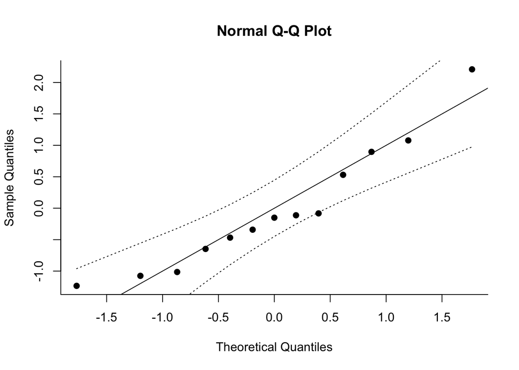

```
##
## Random-Effects Model (k = 13; tau^2 estimator: REML)
##
## tau^2 (estimated amount of total heterogeneity): 0.0586 (SE = 0.0375)
## tau (square root of estimated tau^2 value):      0.2422
## I^2 (total heterogeneity / total variability):   69.81%
## H^2 (total variability / sampling variability):  3.31
##
## Test for Heterogeneity:
## Q(df = 12) = 43.4606, p-val < .0001
##
## Model Results:
##
## estimate      se    zval    pval   ci.lb   ci.ub
##   0.2728  0.0848  3.2169  0.0013  0.1066  0.4390  **
##
## ---
## Signif. codes:  0 '***' 0.001 '**' 0.01 '*' 0.05 '.' 0.1 ' ' 1
```

```
##
##        estimate   ci.lb   ci.ub
## tau^2    0.0586  0.0147  0.1782
## tau      0.2422  0.1212  0.4221
## I^2(%)  69.8114 36.6906 87.5433
## H^2      3.3125  1.5795  8.0278
```

### Forest plot

The size of the square represents the weight of the study on the overall estimates. (i.e. studies with more precise measures - think smaller standard errors of the mean = greater weight - have a greater influence on the summary estimates)

We will visualise the summary estimates from the random-effects MA as a diamond just above the x axis. The edges of the diamond are the CIs so if the diamond does not cross the 0 line we have a significant association.

I have also written some code to add the heterogeneity and summary p vals to the bottom of the graph (I wrote this before I realised the metafor website has all the answers to life’s problems so it may not be as neat as it could be)

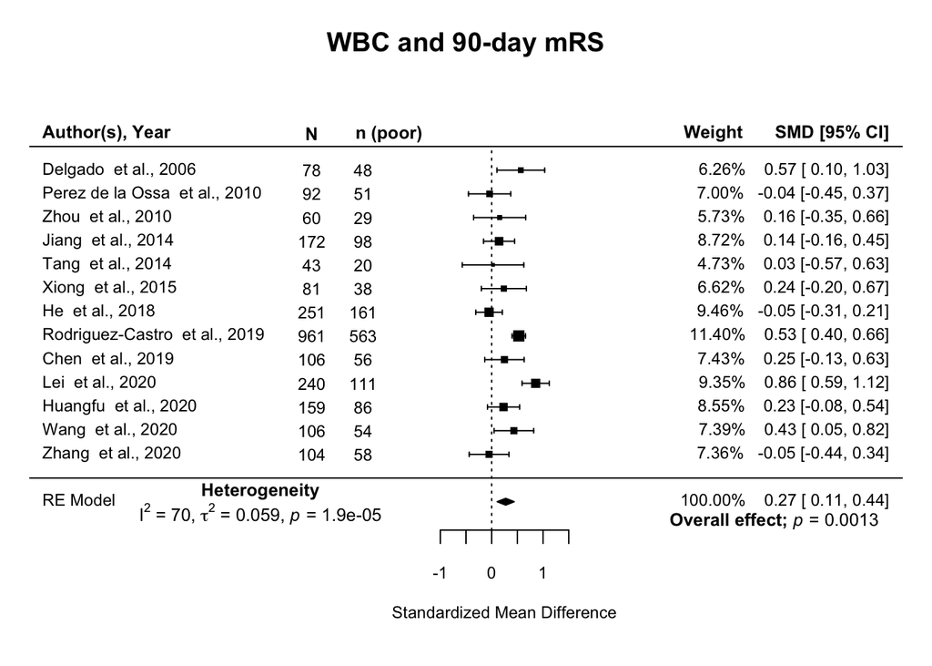

## Sensitivity analysis:

In this part of the analysis we will work out how robust our model is to potential outliers. You will be unable to run some of this analysis when study numbers are low. So clearly, any MA composed of low numbers of studies needs to be interpreted with caution.

### Identifying potential outliers

First up is a Baujat plot identifying studies that heavily contribute to the overall heterogeneity. The studies in the top right quadrant have the most influence on the model, but this is not to say they are statistical outliers.

Ref: Baujat, B., Mahé, C., Pignon, J.-P., & Hill, C. (2002). A graphical method for exploring heterogeneity in meta-analyses: Application to a meta-analysis of 65 trials. Statistics in Medicine, 21(18), 2641–2652.

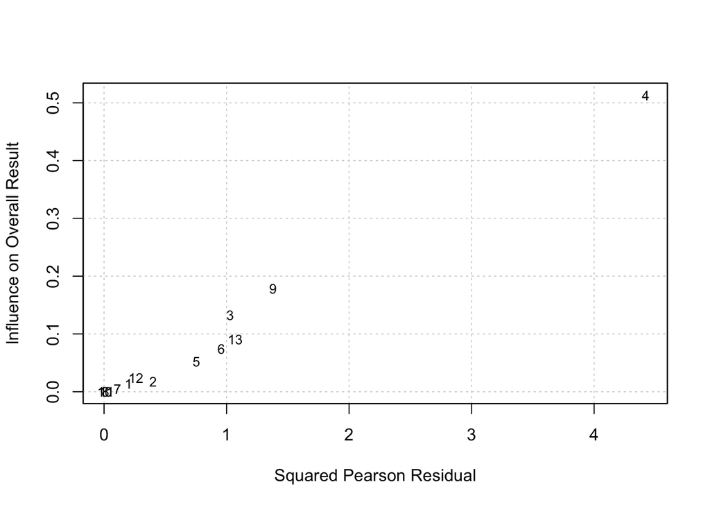

### Outlier plots

Any study that meets outlier cutoffs will be marked in the inf column of the data table.

Before removing an outlier from the model, first learn more about the study to ascertain why it might be acting as an outlier (e.g. are any of the covariates uniquely different or is the study design/population different to the rest) - this might reveal some insight into factors driving heterogeneity.

More information on these plots can be found at : https://www.metafor-project.org/doku.php/plots:plot_of_influence_diagnostics

```
##
##                                rstudent  dffits cook.d  cov.r tau2.del  QE.del
## Jiang  et al., 2014             -0.4488 -0.1241 0.0164 1.1619   0.0641 41.3217
## Tang  et al., 2014              -0.6423 -0.1389 0.0195 1.0740   0.0607 42.2345
## Rodriguez-Castro  et al., 2019   1.0867  0.3888 0.1485 1.1154   0.0575 33.3322
## Lei  et al., 2020                2.7328  0.7804 0.3859 0.7514   0.0305 28.7159
## Delgado  et al., 2006            0.8904  0.2367 0.0570 1.0909   0.0606 42.6875
## Perez de la Ossa  et al., 2010  -1.0201 -0.2824 0.0790 1.0630   0.0576 39.6343
## Zhou  et al., 2010              -0.3331 -0.0720 0.0054 1.1118   0.0629 42.8081
## Xiong  et al., 2015             -0.1054 -0.0137 0.0002 1.1400   0.0643 43.1388
## He  et al., 2018                -1.2994 -0.4473 0.1828 1.0247   0.0521 32.5505
## Chen  et al., 2019              -0.0749 -0.0051 0.0000 1.1584   0.0651 43.1073
## Huangfu  et al., 2020           -0.1391 -0.0245 0.0007 1.1803   0.0658 42.7428
## Wang  et al., 2020               0.5213  0.1613 0.0274 1.1424   0.0638 43.3261
## Zhang  et al., 2020             -1.0880 -0.3119 0.0953 1.0556   0.0567 38.9000
##                                   hat  weight    dfbs inf
## Jiang  et al., 2014            0.0872  8.7235 -0.1244
## Tang  et al., 2014             0.0473  4.7261 -0.1382
## Rodriguez-Castro  et al., 2019 0.1140 11.3991  0.3877
## Lei  et al., 2020              0.0935  9.3462  0.7553
## Delgado  et al., 2006          0.0626  6.2591  0.2361
## Perez de la Ossa  et al., 2010 0.0700  7.0043 -0.2826
## Zhou  et al., 2010             0.0573  5.7251 -0.0716
## Xiong  et al., 2015            0.0662  6.6229 -0.0136
## He  et al., 2018               0.0946  9.4643 -0.4443
## Chen  et al., 2019             0.0743  7.4283 -0.0050
## Huangfu  et al., 2020          0.0855  8.5456 -0.0246
## Wang  et al., 2020             0.0739  7.3915  0.1609
## Zhang  et al., 2020            0.0736  7.3640 -0.3122
```

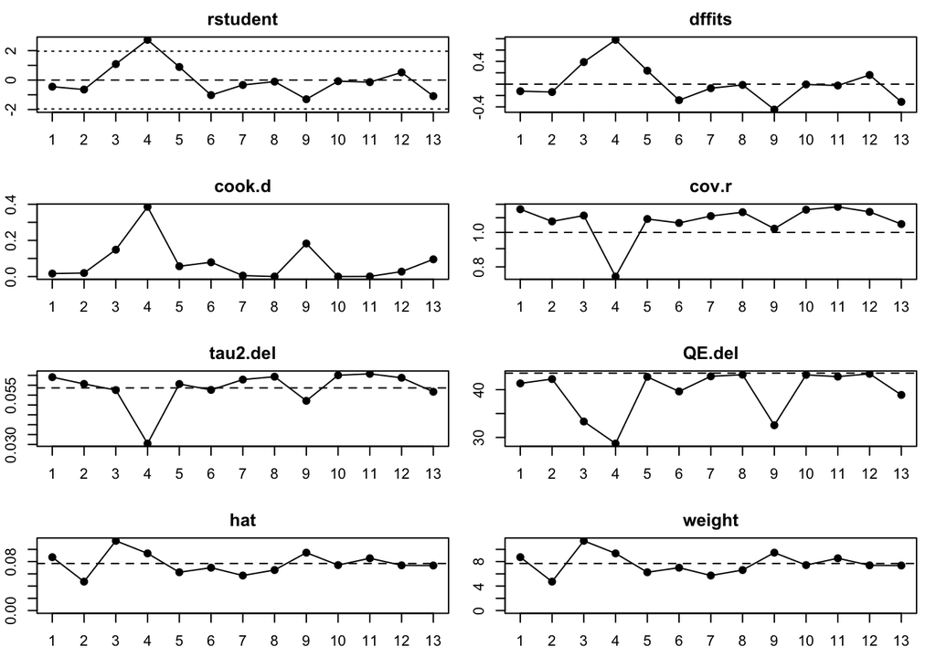

### Leave one out

Now we will repeat the MA but remove a single study each time to determine if our summary estimates are reliant on one study. N.B. Pay special attention to any studies highlighted in the previous plots.

```
##
##                                estimate    se  zval  pval ci.lb ci.ub      Q
## Jiang  et al., 2014               0.284 0.091 3.103 0.002 0.104 0.463 41.322
## Tang  et al., 2014                0.285 0.088 3.239 0.001 0.112 0.457 42.235
## Rodriguez-Castro  et al., 2019    0.240 0.090 2.681 0.007 0.065 0.416 33.332
## Lei  et al., 2020                 0.220 0.074 2.994 0.003 0.076 0.364 28.716
## Delgado  et al., 2006             0.253 0.089 2.851 0.004 0.079 0.426 42.688
## Perez de la Ossa  et al., 2010    0.297 0.087 3.393 0.001 0.125 0.468 39.634
## Zhou  et al., 2010                0.279 0.089 3.120 0.002 0.104 0.454 42.808
## Xiong  et al., 2015               0.274 0.091 3.026 0.002 0.097 0.451 43.139
## He  et al., 2018                  0.309 0.086 3.600 0.000 0.141 0.477 32.551
## Chen  et al., 2019                0.273 0.091 2.994 0.003 0.094 0.452 43.107
## Huangfu  et al., 2020             0.275 0.092 2.985 0.003 0.094 0.455 42.743
## Wang  et al., 2020                0.259 0.091 2.855 0.004 0.081 0.436 43.326
## Zhang  et al., 2020               0.299 0.087 3.432 0.001 0.128 0.470 38.900
##                                   Qp  tau2     I2    H2
## Jiang  et al., 2014            0.000 0.064 71.276 3.481
## Tang  et al., 2014             0.000 0.061 71.757 3.541
## Rodriguez-Castro  et al., 2019 0.000 0.058 62.647 2.677
## Lei  et al., 2020              0.003 0.030 53.337 2.143
## Delgado  et al., 2006          0.000 0.061 71.381 3.494
## Perez de la Ossa  et al., 2010 0.000 0.058 70.076 3.342
## Zhou  et al., 2010             0.000 0.063 72.259 3.605
## Xiong  et al., 2015            0.000 0.064 72.465 3.632
## He  et al., 2018               0.001 0.052 65.999 2.941
## Chen  et al., 2019             0.000 0.065 72.381 3.621
## Huangfu  et al., 2020          0.000 0.066 71.949 3.565
## Wang  et al., 2020             0.000 0.064 71.998 3.571
## Zhang  et al., 2020            0.000 0.057 69.572 3.286
```

## Publication bias assessment

Now we will check to see if there is any evidence of publication bias in our review of the literature.

### Funnel plot

First up is a funnel plot that many use to visually guide analysis of publication bias. In this plot our individual study SMD is plotted on the x axis against the standard error on the y axis. A line is drawn on the summary estimate SMD and asymmetry around this point (vertical dotted line) could indicate a bias in the type of associations reported because there is a relationship between the effect size and precision reported in the literature.

Here is a better guide to interpreting funnel plots: https://www.bmj.com/content/343/bmj.d4002

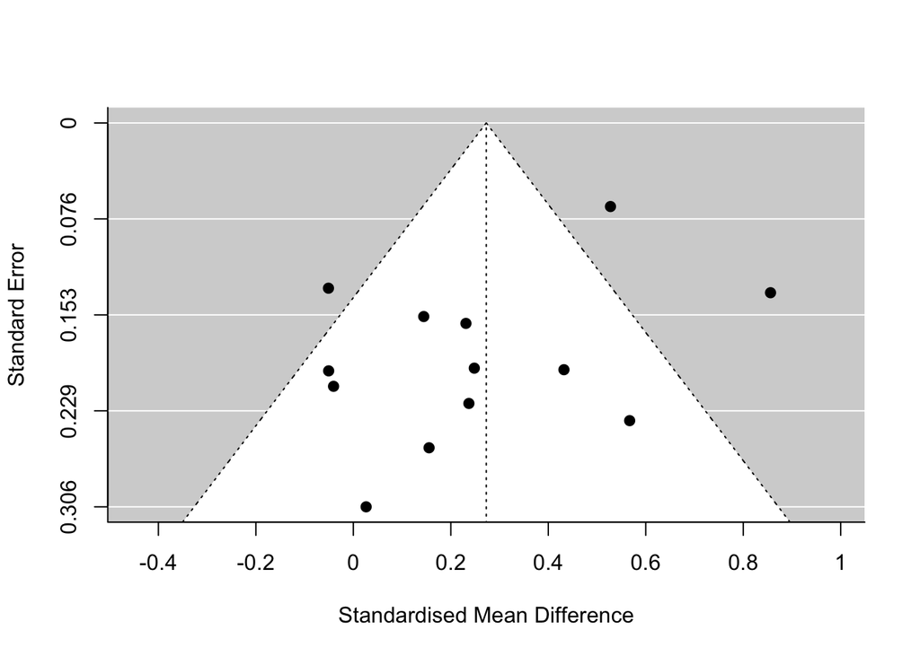

Egger’s test works by regressing the [observed effect sizes divided by their standard error] (y) (essentially z-scores of the effect sizes) against the [inverse of the studies standard error] (x) (equivalent to the precision).

y = B0 + B1x

Egger’s test focuses on B0 to test whether the intercept of our regression significantly deviates from 0.

The intercept is the value of y when predictors are 0 (when standard error is infinitely large). Therefore, we should get a big spread of datapoints around 0 at the intercept because confidence intervals should be extremely large (thus making it nigh on impossible to find significant results - z value > 1.96). If there is small study bias we would expect over-representation of significant studies here (z > 1.96) pulling the intercept away from 0.

I tried to explain that after digesting it but if it doesn’t make sense you can find a much better explanation here: https://bookdown.org/MathiasHarrer/Doing_Meta_Analysis_in_R/pub-bias.html

Ref for the test: https://pubmed.ncbi.nlm.nih.gov/9310563/

## Moderators

In this section we will test if pre-defined study-level variates explain some of the heterogeneity in our random-effects MA by including them as moderators in the equation.

I have also included graphs of (1) a linear regression of the moderator against the SMD with the size of the points reflective of the study’s precision (graphically evaluate influence of single studies). (2) qqnorm graphs explained earlier. (3) model residuals vs fitted values to check that the data are homoskedastic.

### Testing for the effect of cohort age

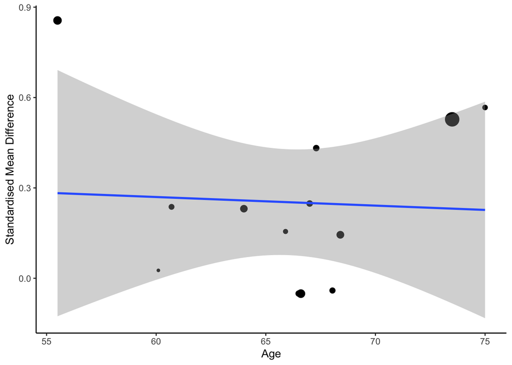

```
##
## Mixed-Effects Model (k = 13; tau^2 estimator: REML)
##
## tau^2 (estimated amount of residual heterogeneity):     0.0640 (SE = 0.0422)
## tau (square root of estimated tau^2 value):             0.2530
## I^2 (residual heterogeneity / unaccounted variability): 68.13%
## H^2 (unaccounted variability / sampling variability):   3.14
## R^2 (amount of heterogeneity accounted for):            0.00%
##
## Test for Residual Heterogeneity:
## QE(df = 11) = 43.4503, p-val < .0001
##
## Test of Moderators (coefficient 2):
## QM(df = 1) = 0.1673, p-val = 0.6825
##
## Model Results:
##
##          estimate      se     zval    pval    ci.lb   ci.ub
## intrcpt    0.7310  1.1265   0.6489  0.5164  -1.4769  2.9388
## age       -0.0069  0.0170  -0.4090  0.6825  -0.0402  0.0263
##
## ---
## Signif. codes:  0 '***' 0.001 '**' 0.01 '*' 0.05 '.' 0.1 ' ' 1
```

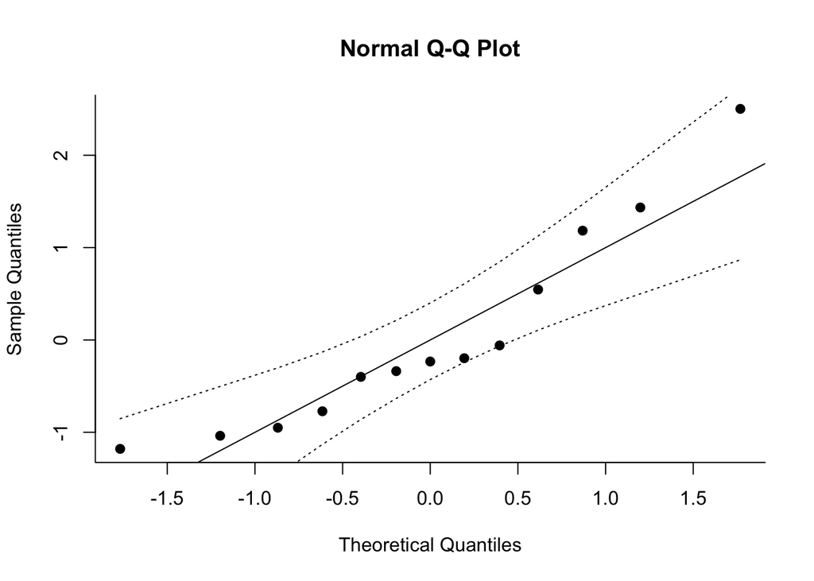

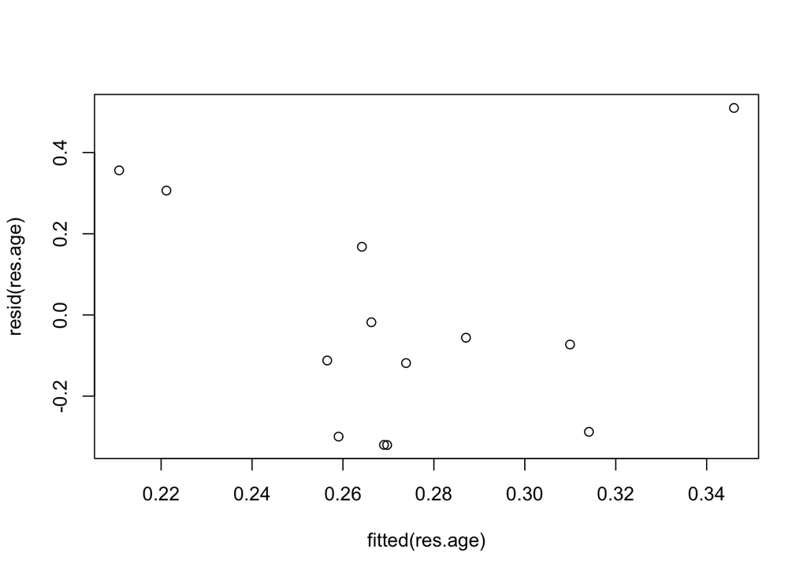

### Testing for the effect of cohort ICH vol

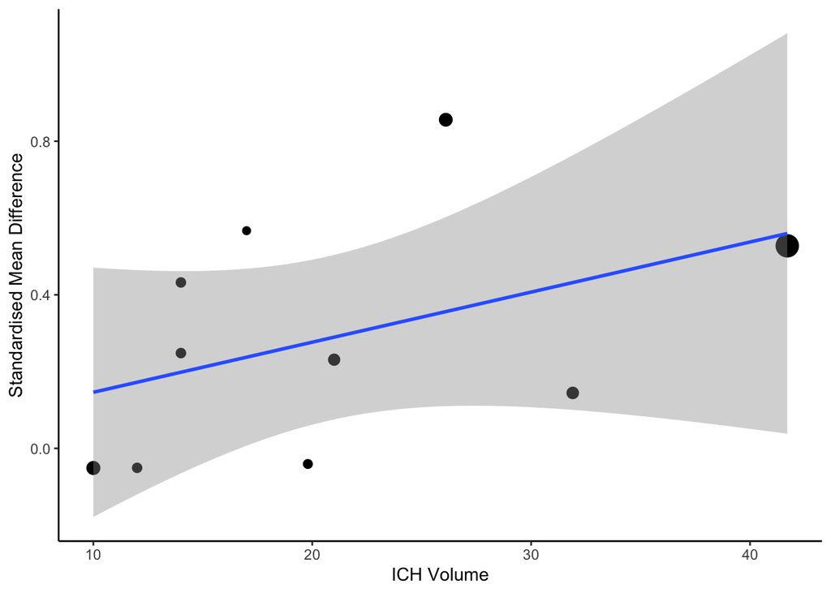

```
##
## Mixed-Effects Model (k = 10; tau^2 estimator: REML)
##
## tau^2 (estimated amount of residual heterogeneity):     0.0595 (SE = 0.0447)
## tau (square root of estimated tau^2 value):             0.2440
## I^2 (residual heterogeneity / unaccounted variability): 68.62%
## H^2 (unaccounted variability / sampling variability):   3.19
## R^2 (amount of heterogeneity accounted for):            18.03%
##
## Test for Residual Heterogeneity:
## QE(df = 8) = 26.6264, p-val = 0.0008
##
## Test of Moderators (coefficient 2):
## QM(df = 1) = 2.1801, p-val = 0.1398
##
## Model Results:
##
##          estimate      se    zval    pval    ci.lb   ci.ub
## intrcpt    0.0023  0.2208  0.0103  0.9918  -0.4306  0.4351
## ich_vol    0.0135  0.0092  1.4765  0.1398  -0.0044  0.0315
##
## ---
## Signif. codes:  0 '***' 0.001 '**' 0.01 '*' 0.05 '.' 0.1 ' ' 1
```

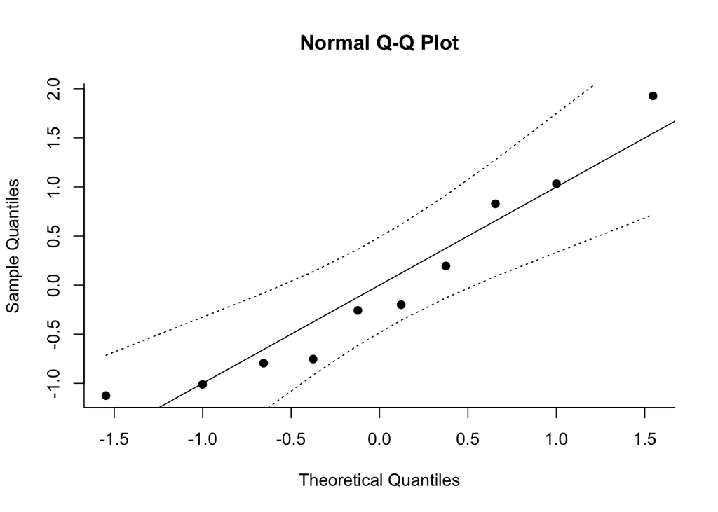

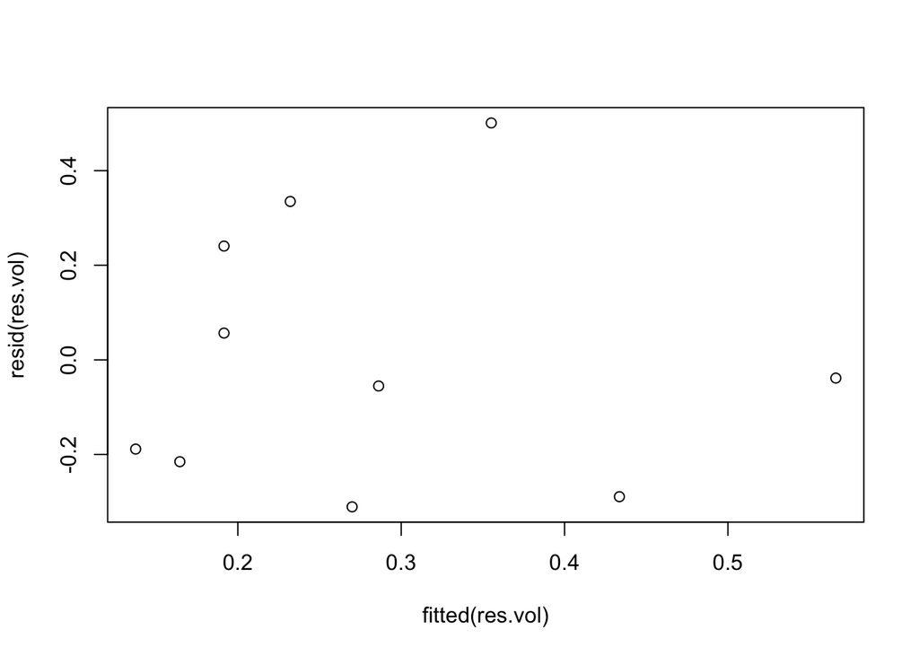

## Subgroup Analysis

In this section we will dichotomise our studies into high quality (risk of bias < 2) and low quality (risk of bias > 1) and perform a metaregression to determine if study quality affected summary estimates.

### Risk of Bias summary

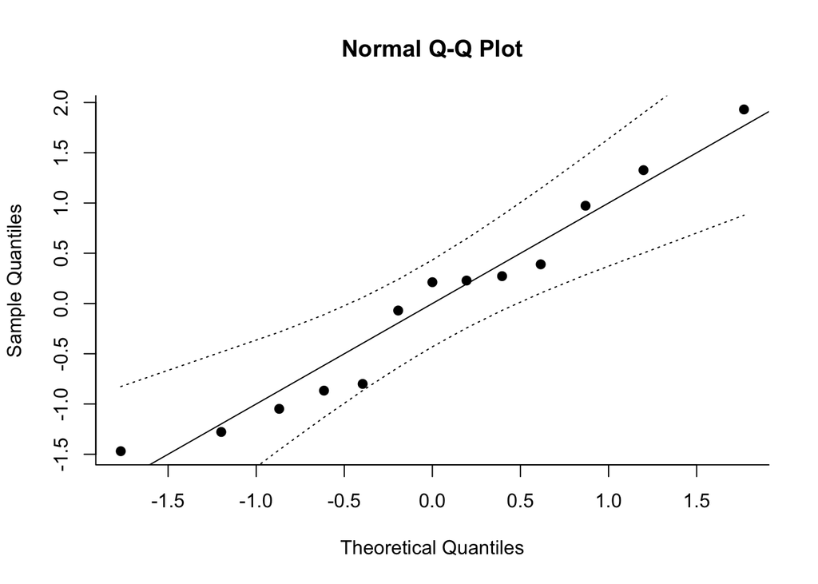

```
##
## Mixed-Effects Model (k = 13; tau^2 estimator: REML)
##
##   logLik  deviance       AIC       BIC      AICc
##  -1.2791    2.5582    8.5582    9.7518   11.9867
##
## tau^2 (estimated amount of residual heterogeneity):     0.0387 (SE = 0.0306)
## tau (square root of estimated tau^2 value):             0.1968
## I^2 (residual heterogeneity / unaccounted variability): 57.37%
## H^2 (unaccounted variability / sampling variability):   2.35
## R^2 (amount of heterogeneity accounted for):            33.97%
##
## Test for Residual Heterogeneity:
## QE(df = 11) = 24.7234, p-val = 0.0100
##
## Test of Moderators (coefficient 2):
## QM(df = 1) = 3.3715, p-val = 0.0663
##
## Model Results:
##
##                      estimate      se    zval    pval    ci.lb   ci.ub
## intrcpt                0.1771  0.0930  1.9044  0.0569  -0.0052  0.3594  .
## subgroupLow Quality    0.2857  0.1556  1.8362  0.0663  -0.0193  0.5906  .
##
## ---
## Signif. codes:  0 '***' 0.001 '**' 0.01 '*' 0.05 '.' 0.1 ' ' 1
```

### Subgroup Forest plot

Now we will generate a forest plot containing our dichotomised studies and the relevant summary estimates.

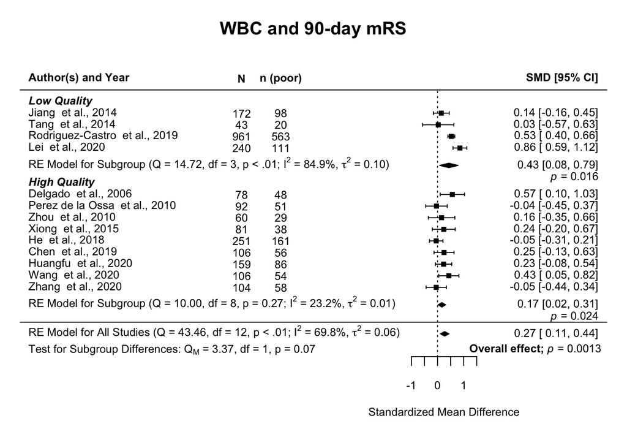